# Variable selection

UW 2020 short course

NIMBLE Development Team

# Bayesian variable selection

- You have many candidate explanatory variables.
- Bayesian approach is to have a probability that a variable is included in the model.
- Really this is a probability that the coefficient is $\ne 0$.
- BUGS/JAGS implementation is with indicator variables.

```
  logit(psi[i]) <- beta0 + ind * beta1 * vegHt[i]
```

- This has problems: when `ind` is 0, `beta1` follows its prior, until it hits a reasonable value for beta1 that allows `ind` equal to 1 to be accepted.
- “Solution”: informative priors

# Solution!: Reversible Jump MCMC

- RJMCMC is a method for sampling across different models.
- Specifically it is about sampling between different numbers of dimensions.
- In full generality, RJ requires one to figure out a way to propose reasonable parameter values when moving between models. Hard!
- RJ for variable selection is relatively simple.
  - We don’t change the actual NIMBLE model object, but we turn on and off which dimensions are sampled.
  - Implementation, like all samplers, is written using `nimbleFunction`s.

# RJMCMC for variable selection in nimble

- Update an MCMC configuration to use RJMCMC.

```r
occ_model_sel <- occ_model$newModel(replicate = TRUE)
```

```
## checking model sizes and dimensions... This model is not fully initialized. This is not an error. To see which variables are not initialized, use model$initializeInfo(). For more information on model initialization, see help(modelInitialization).
```

```r
Cocc_model_sel <- compileNimble(occ_model_sel)
```

```
## compiling... this may take a minute. Use 'showCompilerOutput = TRUE' to see C++ compilation details.
## compilation finished.
```

```r
conf_sel <- configureMCMC(occ_model_sel)
configureRJ(conf_sel,
            targetNodes = 'beta1',
            priorProb = 0.5,
            control = list(mean = 0, scale = 2))
occ_MCMC_sel <- buildMCMC(conf_sel)

Cocc_MCMC_sel <- compileNimble(occ_MCMC_sel, project = occ_model_sel)
```

```
## compiling... this may take a minute. Use 'showCompilerOutput = TRUE' to see C++ compilation details.
## compilation finished.
```

# Run the RJMCMC

```r
samples_sel <- runMCMC(Cocc_MCMC_sel, niter = 2500)
```

```
## running chain 1...
```

```
## |-------------|-------------|-------------|-------------|
## |-------------------------------------------------------|
```

```r
mean(samples_sel[ , 'beta1'] != 0)
```

```
## [1] 0.9924
```

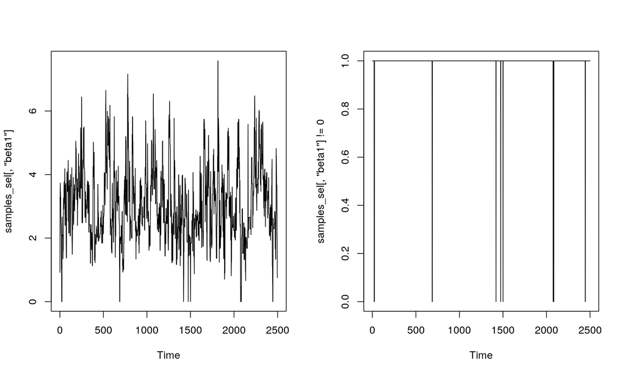

```r
par(mfrow = c(1,2))
ts.plot(samples_sel[ , 'beta1'])
ts.plot(samples_sel[ , 'beta1'] != 0)
```

# A more interesting case

Let’s set the true beta1 equal to 1.

```r
set.seed(1)                   # So we all get same data set
M <- 100                      # Number of sites
J <- 3                        # Number of presence/absence measurements
y <- matrix(NA, nrow = M, ncol = J) # to contain the obs. data

# Create a covariate called vegHt
vegHt <- sort(runif(M, -1, 1)) # sort for graphical convenience

# Choose parameter values for occupancy model and compute occupancy
beta0 <- 0                    # Logit-scale intercept
beta1 <- 1                   # Logit-scale slope for vegHt
psi <- plogis(beta0 + beta1 * vegHt) # Occupancy probability
# plot(vegHt, psi, ylim = c(0,1), type = "l", lwd = 3) # Plot psi relationship

# Now visit each site and observe presence/absence perfectly
z <- rbinom(M, 1, psi)        # True presence/absence

wind <- array(runif(M * J, -1, 1), dim = c(M, J))

# Choose parameter values for measurement error model and compute detectability
alpha0 <- -2                        # Logit-scale intercept
alpha1 <- -3                        # Logit-scale slope for wind
p <- plogis(alpha0 + alpha1 * wind) # Detection probability
# plot(p ~ wind, ylim = c(0,1))     # Look at relationship

# Take J = 3 presence/absence measurements at each site
for(j in 1:J) {
  y[,j] <- rbinom(M, z, p[,j])
}

time <- matrix(rep(as.character(1:J), M), ncol = J, byrow = TRUE)
hab <- c(rep("A", 33), rep("B", 33), rep("C", 34))  # Must have M = 100

# Bundle and summarize data set
occupancy_data2 <- list(y = y,
                            vegHt = vegHt,
                            wind = wind,
                            M = nrow(y),
                            J = ncol(y),
                            XvegHt = seq(-1, 1, length.out=100),
                            Xwind = seq(-1, 1, length.out=100))

zst <- apply(y, 1, max)        # Avoid data/model/inits conflict
inits_saved2 <- occupancy_inits()
```

Now run again. (I haven’t been able to diagnose the ‘logProb’ warnings – they don’t occur when I run directly in R, only when creating the html.)

```r
occ_model_sel <- nimbleModel(occ_code,
                        constants = occupancy_data2,
                        inits = inits_saved2)
```

```
## defining model...
```

```
## Detected y as data within 'constants'.
```

```
## Adding y as data for building model.
```

```
## building model...
```

```
## setting data and initial values...
```

```
## running calculate on model (any error reports that follow may simply reflect missing values in model variables) ...
## checking model sizes and dimensions...
## model building finished.
```

```r
Cocc_model_sel <- compileNimble(occ_model_sel)
```

```
## compiling... this may take a minute. Use 'showCompilerOutput = TRUE' to see C++ compilation details.
## compilation finished.
```

```r
conf_sel <- configureMCMC(occ_model_sel)
configureRJ(conf_sel,
            targetNodes = 'beta1',
            priorProb = 0.5,
            control = list(mean = 0, scale = 2))
occ_MCMC_sel <- buildMCMC(conf_sel)

Cocc_MCMC_sel <- compileNimble(occ_MCMC_sel, project = occ_model_sel)
```

```
## compiling... this may take a minute. Use 'showCompilerOutput = TRUE' to see C++ compilation details.
## compilation finished.
```

```r
samples_sel <- runMCMC(Cocc_MCMC_sel, niter = 2500)
```

```
## running chain 1...
```

```
## warning: logProb of data node y[12, 3]: logProb is -Inf.
## warning: logProb of data node y[20, 1]: logProb is -Inf.
## warning: logProb of data node y[25, 3]: logProb is -Inf.
## warning: logProb of data node y[45, 3]: logProb is -Inf.
## warning: logProb of data node y[48, 1]: logProb is -Inf.
## warning: logProb of data node y[54, 3]: logProb is -Inf.
## warning: logProb of data node y[57, 1]: logProb is -Inf.
## warning: logProb of data node y[67, 1]: logProb is -Inf.
## warning: logProb of data node y[82, 2]: logProb is -Inf.
## warning: logProb of data node y[82, 3]: logProb is -Inf.
## warning: logProb of data node y[93, 3]: logProb is -Inf.
## |-------------|-------------|-------------|-------------|
## |-------------------------------------------------------|
```

```r
mean(samples_sel[ , 'beta1'] != 0)
```

```
## [1] 0.144
```

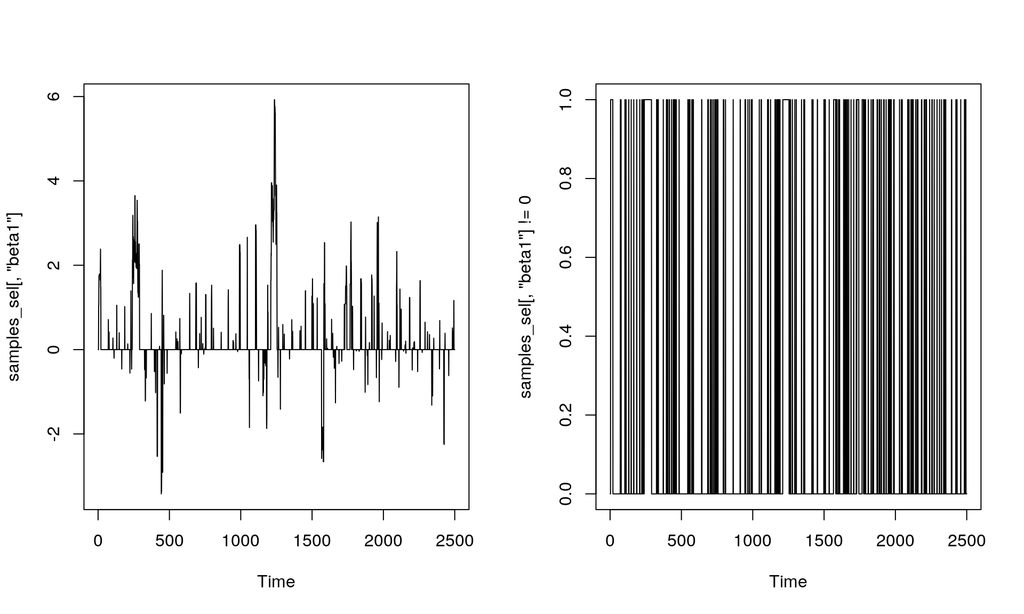

```r
par(mfrow = c(1,2))
ts.plot(samples_sel[ , 'beta1'])
ts.plot(samples_sel[ , 'beta1'] != 0)
```

# Summary of RJMCMC

- Mixing will generally be better than simply using an indicator function.
- One can use RJ for variable selection in NIMBLE either with or without indicator functions.
- Adaptation for coefficient samplers only occurs when the coefficient is “in the model”.
- Run time should be much faster *if* posterior probability of inclusion is not large.
- Tuning parameter of RJ proposal scale (sd) must be chosen.

# Using indicator variables without RJMCMC

For reference, here is how one would do it with an indicator variable but without RJMCMC. How much worse this is will depend on the posterior probability of inclusion and the priors on the coefficient being considered for inclusion.

```r
occ_code_ind <- nimbleCode({
  # Priors
  mean.p ~ dunif(0, 1)         # Detection intercept on prob. scale
  alpha0 <- logit(mean.p)      # Detection intercept
  alpha1 ~ dunif(-20, 20)      # Detection slope on wind
  mean.psi ~ dunif(0, 1)       # Occupancy intercept on prob. scale
  beta0 <- logit(mean.psi)     # Occupancy intercept
  beta1 ~ dunif(-20, 20)       # Occupancy slope on vegHt

  # Likelihood
  for (i in 1:M) {
    # True state model for the partially observed true state
    z[i] ~ dbern(psi[i])      # True occupancy z at site i
    logit(psi[i]) <- beta0 + ind * beta1 * vegHt[i]
    for (j in 1:J) {
      # Observation model for the actual observations
      y[i,j] ~ dbern(p.eff[i,j])    # Detection-nondetection at i and j
      p.eff[i,j] <- z[i] * p[i,j]   # 'straw man' for WinBUGS
      logit(p[i,j]) <- alpha0 + alpha1 * wind[i,j]
    }
  }
  ind ~ dbern(0.5)
  # Derived quantities are removed.
}
)

occ_model_ind <- nimbleModel(occ_code_ind,
                        constants = occupancy_data2,
                        inits = c(inits_saved2, ind = 1))
```

```
## defining model...
```

```
## Detected y as data within 'constants'.
```

```
## Adding y as data for building model.
```

```
## building model...
```

```
## setting data and initial values...
```

```
## running calculate on model (any error reports that follow may simply reflect missing values in model variables) ...
## checking model sizes and dimensions...
## model building finished.
```

```r
Cocc_model_ind  <- compileNimble(occ_model_ind )
```

```
## compiling... this may take a minute. Use 'showCompilerOutput = TRUE' to see C++ compilation details.
## compilation finished.
```

```r
occ_MCMC_ind  <- buildMCMC(occ_model_ind )


Cocc_MCMC_ind  <- compileNimble(occ_MCMC_ind , project = occ_model_ind )
```

```
## compiling... this may take a minute. Use 'showCompilerOutput = TRUE' to see C++ compilation details.
## compilation finished.
```

```r
samples_ind <- runMCMC(Cocc_MCMC_ind, niter = 2500)
```

```
## running chain 1...
```

```
## warning: logProb of data node y[12, 3]: logProb is -Inf.
## warning: logProb of data node y[20, 1]: logProb is -Inf.
## warning: logProb of data node y[25, 3]: logProb is -Inf.
## warning: logProb of data node y[45, 3]: logProb is -Inf.
## warning: logProb of data node y[48, 1]: logProb is -Inf.
## warning: logProb of data node y[54, 3]: logProb is -Inf.
## warning: logProb of data node y[57, 1]: logProb is -Inf.
## warning: logProb of data node y[67, 1]: logProb is -Inf.
## warning: logProb of data node y[82, 2]: logProb is -Inf.
## warning: logProb of data node y[82, 3]: logProb is -Inf.
## warning: logProb of data node y[93, 3]: logProb is -Inf.
## |-------------|-------------|-------------|-------------|
## |-------------------------------------------------------|
```

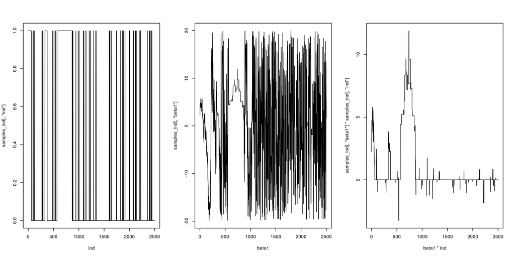

```r
par(mfrow = c(1,3))
ts.plot(samples_ind[ , 'ind'], xlab = 'ind')
ts.plot(samples_ind[ , 'beta1'], xlab = 'beta1')
ts.plot(samples_ind[ , 'beta1'] * samples_ind[ , 'ind'],
        xlab = 'beta1 * ind')
```